# FigureYa97correlationV3

小丫画图出品

2019-11-7

欢迎关注“小丫画图”公众号，同名知识星球等你加入

小丫微信: epigenomics E-mail: figureya@126.com

作者：果子，欢迎关注“果子学生信”公众号

小丫编辑校验

## 需求描述

计算多个基因和免疫浸润的相关性，画出类似于文章中这种热图，用颜色展示相关系数，用**标出显著的。

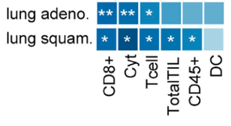

出自https://www.nature.com/articles/s41586-019-1032-7

## 应用场景

评价基因对免疫浸润的影响，甚至可以批量筛选出影响免疫浸润的候选基因。

其本质是计算两种特征之间的相关性，此处的免疫浸润可以换成其他变量，例如临床表型等等。

如果要同时展示两个基因之间的相关性，及其与免疫浸润之间的关系，请参考“FigureYa96R2”。

## 环境设置

加载包

```r
library(ggplot2)
library(dplyr)
Sys.setenv(LANGUAGE = "en") #显示英文报错信息
options(stringsAsFactors = FALSE) #禁止chr转成factor
```

## 输入文件

要求前两个文件的样本名一致

- ssGSEA_output.csv，免疫细胞矩阵，列是免疫细胞，行是样本，由FigureYa71ssGSEA产生。如果对免疫浸润不感兴趣，就把ssGSEA_output.csv换成其他类型的数据，例如临床指标什么的，只要保证样品名跟easy_input_expr.csv一致就好了。
- easy_input_expr.csv，基因表达矩阵，列是样本，行是基因。行也可以是转录本，甚至是临床信息。
- genelist.txt，基因名，将要计算这些基因跟免疫浸润的相关性。要求跟easy_input_expr.csv里的基因名一致。

```r
### 读入ssGSEA的结果
tcga_gsva <- read.csv("ssGSEA_output.csv",row.names = 1)
rownames(tcga_gsva) <- gsub("\\.","-",rownames(tcga_gsva))
head(tcga_gsva)[,1:3]
```

```
##                                      aDC    B.cells CD8.T.cells
## TCGA-AZ-4315-01A-01R-1410-07 0.083169005 -0.1889819   0.2952356
## TCGA-AA-3667-01A-01R-0905-07 0.006564773 -0.2113703   0.2580641
## TCGA-F4-6854-01A-11R-1928-07 0.098793288 -0.2075188   0.2637370
## TCGA-AA-3815-01A-01R-1022-07 0.256035294 -0.1512010   0.3320728
## TCGA-AA-3509-01A-01R-1410-07 0.053441800 -0.2027833   0.2704839
## TCGA-DM-A0XF-01A-11R-A155-07 0.027041650 -0.2250856   0.2775022
```

```r
### 读入表达量数据
tcga_expr <- data.table::fread("easy_input_expr.csv", data.table = F, )
## 第一列转为行名
rownames(tcga_expr) <- tcga_expr[,1]
tcga_expr <- tcga_expr[,-1]
## 调整免疫矩阵中的样本顺序
tcga_gsva <- tcga_gsva[colnames(tcga_expr),]
tcga_expr[1:3,1:4]
```

```
##            TCGA-AZ-4315-01A-01R-1410-07 TCGA-AA-3667-01A-01R-0905-07
## OR4F5                               0.0                          0.0
## FO538757.3                          0.0                          0.0
## FO538757.2                          3.2                          7.7
##            TCGA-F4-6854-01A-11R-1928-07 TCGA-AA-3815-01A-01R-1022-07
## OR4F5                               0.0                          0.0
## FO538757.3                          0.0                          0.0
## FO538757.2                          6.7                          2.1
```

```r
### 读入感兴趣的基因
genelist <- read.table("genelist.txt")
genelist <- genelist$V1
```

## 批量计算相关性

先写一个函数

输入一个基因，即可返回跟免疫基因的相关性、p值

其中method可以改为“pearson”或“kendall”

```r
gene <- genelist
immuscore <- function(gene){
  y <- as.numeric(tcga_expr[gene,])
  colnames <- colnames(tcga_gsva)
  do.call(rbind,lapply(colnames, function(x){
    dd  <- cor.test(as.numeric(tcga_gsva[,x]), y , method="spearman")
    data.frame(gene=gene,immune_cells=x,cor=dd$estimate,p.value=dd$p.value )
  }))
}

#以FOXP3为例，测试一下函数
immuscore("FOXP3")
```

```
##        gene        immune_cells         cor       p.value
## rho   FOXP3                 aDC  0.57649225  2.614828e-58
## rho1  FOXP3             B.cells  0.32584092  2.147663e-17
## rho2  FOXP3         CD8.T.cells  0.30878753  1.077639e-15
## rho3  FOXP3     Cytotoxic.cells  0.53985993  5.410973e-50
## rho4  FOXP3                  DC  0.61734924  6.486865e-69
## rho5  FOXP3         Eosinophils  0.15202509  1.075026e-04
## rho6  FOXP3                 iDC  0.58387037  4.100044e-60
## rho7  FOXP3         Macrophages  0.57050158  7.068755e-57
## rho8  FOXP3          Mast.cells  0.47883634  3.225735e-38
## rho9  FOXP3         Neutrophils  0.42661085  7.233426e-30
## rho10 FOXP3 NK.CD56bright.cells  0.06391603  1.051221e-01
## rho11 FOXP3    NK.CD56dim.cells  0.25662591  3.822291e-11
## rho12 FOXP3            NK.cells  0.41215540  8.418979e-28
## rho13 FOXP3                 pDC  0.36711101  5.599288e-22
## rho14 FOXP3             T.cells  0.56689992  4.967756e-56
## rho15 FOXP3      T.helper.cells  0.07053563  7.365597e-02
## rho16 FOXP3                 Tcm -0.12969783  9.706050e-04
## rho17 FOXP3                 Tem  0.39631475  1.191943e-25
## rho18 FOXP3                 TFH  0.40903830  2.278818e-27
## rho19 FOXP3                 Tgd  0.17295237  1.015640e-05
## rho20 FOXP3           Th1.cells  0.46919848  1.446585e-36
## rho21 FOXP3          Th17.cells -0.05793296  1.419546e-01
## rho22 FOXP3           Th2.cells -0.15549505  7.417455e-05
## rho23 FOXP3                TReg  0.94397989 2.578799e-311
```

### 批量计算genelist跟免疫浸润相关性的结果

```r
data <- do.call(rbind,lapply(genelist,immuscore))
head(data)
```

```
##      gene    immune_cells         cor      p.value
## rho  SCOC             aDC -0.05234405 0.1846172332
## rho1 SCOC         B.cells  0.03127663 0.4281485715
## rho2 SCOC     CD8.T.cells  0.14815086 0.0001611771
## rho3 SCOC Cytotoxic.cells -0.14206481 0.0002985493
## rho4 SCOC              DC -0.14820968 0.0001602010
## rho5 SCOC     Eosinophils -0.05437736 0.1681163534
```

```r
#保存到文件
write.csv(data, "correlation.csv", quote = F, row.names = F)
```

### 增加一列，区分p值的大小

使用两个ifelse实现三分类

```r
data$pstar <- ifelse(data$p.value < 0.05,
                     ifelse(data$p.value < 0.01,"**","*"),
                     "")
data$pstar[1:20]
```

```
##  [1] ""   ""   "**" "**" "**" ""   "**" ""   "*"  "**" "**" "**" "**" "**" ""
## [16] "**" "**" "**" "*"  "**"
```

## 开始画图

使用ggplot2画图，主要用到的是geom_tile函数：

- 相关性用颜色的不同来表示，相关性的大小用颜色的深浅来反映；
- 有差异的把*号打印在热图上

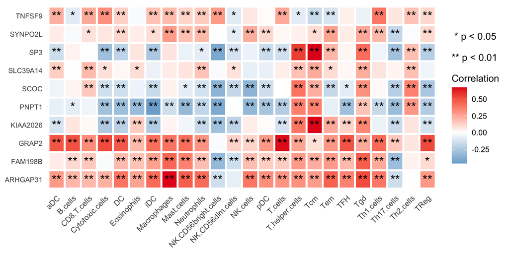

```r
#你可能想要改变横轴细胞的顺序，那就把细胞按照你想要的顺序写入levels = c()的括号里。
#查看细胞名
#unique(data$immune_cells)
#data$immune_cells <- factor(data$immune_cells,
#                            levels = c("第一种细胞","第二种细胞",,,,))

ggplot(data, aes(immune_cells, gene)) +
  geom_tile(aes(fill = cor), colour = "white",size=1)+
  scale_fill_gradient2(low = "#2b8cbe",mid = "white",high = "#e41a1c")+
  geom_text(aes(label=pstar),col ="black",size = 5)+
  theme_minimal()+# 不要背景
  theme(axis.title.x=element_blank(),#不要title
        axis.ticks.x=element_blank(),#不要x轴
        axis.title.y=element_blank(),#不要y轴
        axis.text.x = element_text(angle = 45, hjust = 1),# 调整x轴文字
        axis.text.y = element_text(size = 8))+#调整y轴文字
  #调整legen
  labs(fill =paste0(" * p < 0.05","\n\n","** p < 0.01","\n\n","Correlation"))
```

```r
#保存到文件
ggsave("correlation.pdf", width = 8, height = 4)
```

geom_tile函数中的colour可以改变颜色，例如black

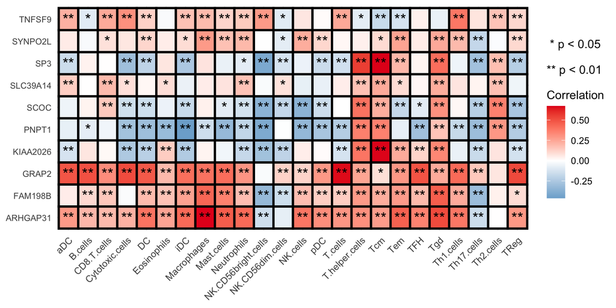

```r
ggplot(data, aes(immune_cells, gene)) +
  geom_tile(aes(fill = cor), colour = "black",size=1)+
  scale_fill_gradient2(low = "#2b8cbe",mid = "white",high = "#e41a1c")+
  geom_text(aes(label=pstar),col ="black",size = 5)+
  theme_minimal()+# 不要背景
  theme(axis.title.x=element_blank(),#不要title
        axis.ticks.x=element_blank(),#不要x轴
        axis.title.y=element_blank(),#不要y轴
        axis.text.x = element_text(angle = 45, hjust = 1),# 调整x轴文字
        axis.text.y = element_text(size = 8))+#调整y轴文字
  #调整legen
  labs(fill =paste0(" * p < 0.05","\n\n","** p < 0.01","\n\n","Correlation"))
```

如果colour缺失，就没有边框的颜色

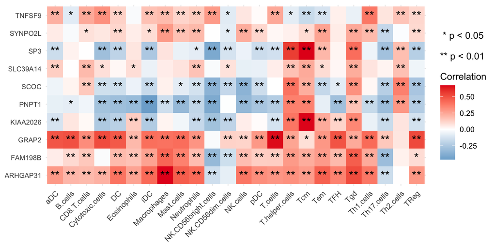

```r
ggplot(data, aes(immune_cells, gene)) +
  geom_tile(aes(fill = cor),size=1)+
  scale_fill_gradient2(low = "#2b8cbe",mid = "white",high = "#e41a1c")+
  geom_text(aes(label=pstar),col ="black",size = 5)+
  theme_minimal()+# 不要背景
  theme(axis.title.x=element_blank(),#不要title
        axis.ticks.x=element_blank(),#不要x轴
        axis.title.y=element_blank(),#不要y轴
        axis.text.x = element_text(angle = 45, hjust = 1),# 调整x轴文字
        axis.text.y = element_text(size = 8))+#调整y轴文字
  #调整legend
  labs(fill =paste0(" * p < 0.05","\n\n","** p < 0.01","\n\n","Correlation"))
```

如果把其他变量映射到size参数，可以实现热图小方块的大小改变

本次不推荐，我觉得不好看

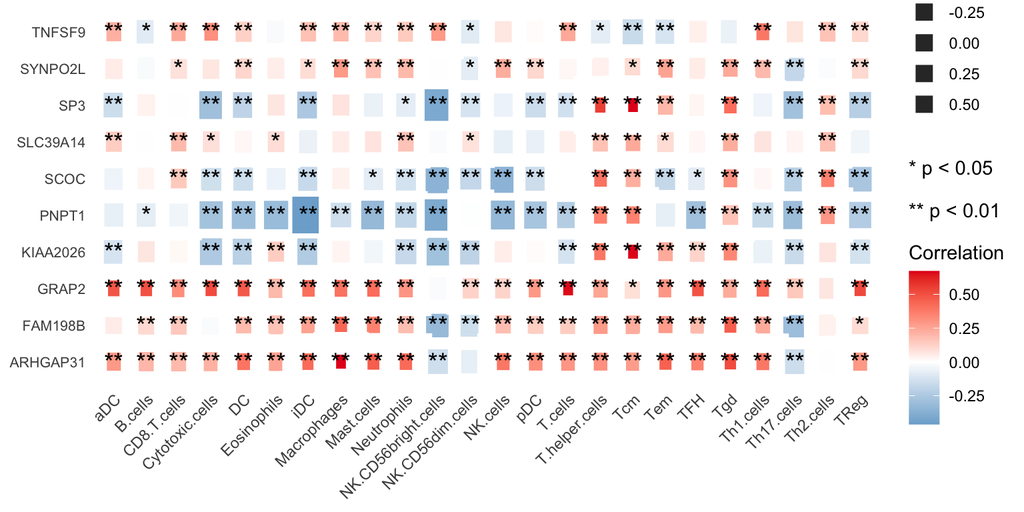

```r
ggplot(data, aes(immune_cells, gene)) +
  geom_tile(aes(fill = cor, size = cor), colour = "white")+
  scale_fill_gradient2(low = "#2b8cbe",mid = "white",high = "#e41a1c")+
  scale_size_continuous(range =c(0,6))+
  geom_text(aes(label=pstar),col ="black",size = 5)+
  theme_minimal()+
  theme(axis.title.x=element_blank(),
        axis.text.x = element_text(angle = 45, hjust = 1),
        axis.ticks.x=element_blank(),
        axis.title.y=element_blank(),
        axis.text.y = element_text(size = 8))+
  labs(fill =paste0("* p < 0.05","\n\n","** p < 0.01","\n\n","Correlation"),size="Correlation")
```